# Natural Disasters Analysis - Yearly Trend

#### Authors: Women of the West Coast (WWC)

#### Date: Oct. 22, 2023

1. Introduction
2. Data Processing
3. Global Analysis
4. Canada-Specific Analysis
5. Insights Summary
6. Conclusion

## Introduction

Natural disasters have been causing significant socio-economic impacts around the globe. Understanding the patterns, economic damages, and loss of life due to these events is crucial for effective crisis response and management. In this report, we analyze global and Canada-specific data on natural disasters to gain insights that can inform and empower response initiatives.

## Data Processing

```python
import pandas as pd
import matplotlib.pyplot as plt

# Filter warnings
from warnings import filterwarnings
filterwarnings('ignore')
```

```python
# Load the two datasets
dataset_1 = pd.read_csv('1900_2021_DISASTERS.xlsx - emdat data.csv')
dataset_2 = pd.read_csv('1970-2021_DISASTERS.xlsx - emdat data.csv')
```

```python
# Set display options to show all columns and rows
pd.set_option('display.max_columns', None)
pd.set_option('display.max_rows', None)
```

```python
# Display the first few rows of dataset_1
dataset_1.head()
```

|  | Year | Seq | Glide | Disaster Group | Disaster Subgroup | Disaster Type | Disaster Subtype | Disaster Subsubtype | Event Name | Country | ISO | Region | Continent | Location | Origin | Associated Dis | Associated Dis2 | OFDA Response | Appeal | Declaration | Aid Contribution | Dis Mag Value | Dis Mag Scale | Latitude | Longitude | Local Time | River Basin | Start Year | Start Month | … |
| --- | --- | --- | --- | --- | --- | --- | --- | --- | --- | --- | --- | --- | --- | --- | --- | --- | --- | --- | --- | --- | --- | --- | --- | --- | --- | --- | --- | --- | --- | --- |
| 0 | 1900 | 9002 | NaN | Natural | Climatological | Drought | Drought | NaN | NaN | Cabo Verde | CPV | Western Africa | Africa | Countrywide | NaN | Famine | NaN | NaN | No | No | NaN | NaN | Km2 | NaN | NaN | NaN | NaN | 1900 | NaN | … |
| 1 | 1900 | 9001 | NaN | Natural | Climatological | Drought | Drought | NaN | NaN | India | IND | Southern Asia | Asia | Bengal | NaN | NaN | NaN | NaN | No | No | NaN | NaN | Km2 | NaN | NaN | NaN | NaN | 1900 | NaN | … |
| 2 | 1902 | 12 | NaN | Natural | Geophysical | Earthquake | Ground movement | NaN | NaN | Guatemala | GTM | Central America | Americas | Quezaltenango, San Marcos | NaN | Tsunami/Tidal wave | NaN | NaN | NaN | NaN | NaN | 8.0 | Richter | 14 | -91 | 20:20 | NaN | 1902 | 4.0 | … |
| 3 | 1902 | 3 | NaN | Natural | Geophysical | Volcanic activity | Ash fall | NaN | Santa Maria | Guatemala | GTM | Central America | Americas | NaN | NaN | NaN | NaN | NaN | NaN | NaN | NaN | NaN | NaN | NaN | NaN | NaN | NaN | 1902 | 4.0 | … |
| 4 | 1902 | 10 | NaN | Natural | Geophysical | Volcanic activity | Ash fall | NaN | Santa Maria | Guatemala | GTM | Central America | Americas | NaN | NaN | NaN | NaN | NaN | NaN | NaN | NaN | NaN | NaN | NaN | NaN | NaN | NaN | 1902 | 10.0 | … |

#### Dataset 1:

Covers the years from 1900 onwards. Contains 45 columns, including details like the year, disaster type, country, number of deaths, economic damages, and more.

```python
# Display the first few rows of dataset_2
dataset_2.head()
```

|  | Dis No | Year | Seq | Glide | Disaster Group | Disaster Subgroup | Disaster Type | Disaster Subtype | Disaster Subsubtype | Event Name | Country | ISO | Region | Continent | Location | Origin | Associated Dis | Associated Dis2 | OFDA Response | Appeal | Declaration | Aid Contribution | Dis Mag Value | Dis Mag Scale | Latitude | Longitude | Local Time | River Basin | Start Year | … |
| --- | --- | --- | --- | --- | --- | --- | --- | --- | --- | --- | --- | --- | --- | --- | --- | --- | --- | --- | --- | --- | --- | --- | --- | --- | --- | --- | --- | --- | --- | --- |
| 0 | 1970-0013-ARG | 1970 | 13 | NaN | Natural | Hydrological | Flood | NaN | NaN | NaN | Argentina | ARG | South America | Americas | Mendoza | NaN | NaN | NaN | NaN | NaN | NaN | NaN | NaN | Km2 | NaN | NaN | NaN | NaN | 1970 | … |
| 1 | 1970-0109-AUS | 1970 | 109 | NaN | Natural | Meteorological | Storm | Tropical cyclone | NaN | Ada | Australia | AUS | Australia and New Zealand | Oceania | Queensland | NaN | NaN | NaN | NaN | NaN | NaN | NaN | NaN | Kph | NaN | NaN | NaN | NaN | 1970 | … |
| 2 | 1970-0044-BEN | 1970 | 44 | NaN | Natural | Hydrological | Flood | NaN | NaN | NaN | Benin | BEN | Western Africa | Africa | Atacora region | NaN | NaN | NaN | Yes | NaN | NaN | NaN | NaN | Km2 | NaN | NaN | NaN | NaN | 1970 | … |
| 3 | 1970-0063-BGD | 1970 | 63 | NaN | Natural | Meteorological | Storm | Tropical cyclone | NaN | NaN | Bangladesh | BGD | Southern Asia | Asia | Khulna, Chittagong | NaN | NaN | NaN | Yes | NaN | NaN | NaN | NaN | Kph | NaN | NaN | NaN | NaN | 1970 | … |
| 4 | 1970-0026-BGD | 1970 | 26 | NaN | Natural | Meteorological | Storm | NaN | NaN | NaN | Bangladesh | BGD | Southern Asia | Asia | NaN | NaN | NaN | NaN | NaN | NaN | NaN | NaN | NaN | Kph | NaN | NaN | NaN | NaN | 1970 | … |

#### Dataset 2:

Covers the years from 1970 onwards. Contains 47 columns, with most columns overlapping with Dataset 1 and a few additional ones.

## Combine datasets

### To effectively combine and analyze the datasets, we'll need to:

1. Identify and handle overlapping years between the datasets.
2. Ensure that the column names and data types are consistent.
3. Merge the datasets based on common columns.

Let's start by examining the common and unique columns between the two datasets.

```python
# Identify common and unique columns between the two datasets
common_columns = set(dataset_1.columns).intersection(set(dataset_2.columns))
unique_to_dataset_1 = set(dataset_1.columns) - set(dataset_2.columns)
unique_to_dataset_2 = set(dataset_2.columns) - set(dataset_1.columns)

common_columns, unique_to_dataset_1, unique_to_dataset_2
```

```
({'Adm Level',
  'Admin1 Code',
  'Admin2 Code',
  'Aid Contribution',
  'Appeal',
  'Associated Dis',
  'Associated Dis2',
  'CPI',
  'Continent',
  'Country',
  'Declaration',
  'Dis Mag Scale',
  'Dis Mag Value',
  'Disaster Group',
  'Disaster Subgroup',
  'Disaster Subsubtype',
  'Disaster Subtype',
  'Disaster Type',
  'End Day',
  'End Month',
  'End Year',
  'Event Name',
  'Geo Locations',
  'Glide',
  'ISO',
  "Insured Damages ('000 US$)",
  'Latitude',
  'Local Time',
  'Location',
  'Longitude',
  'No Affected',
  'No Homeless',
  'No Injured',
  'OFDA Response',
  'Origin',
  'Region',
  'River Basin',
  'Seq',
  'Start Day',
  'Start Month',
  'Start Year',
  'Total Affected',
  "Total Damages ('000 US$)",
  'Total Deaths',
  'Year'},
 set(),
 {'Dis No', "Reconstruction Costs ('000 US$)"})
```

### Here's a summary of the columns in the two datasets:

**Common Columns** (between both datasets):

Both datasets share 45 columns in common, such as 'Year', 'Disaster Type', 'Country', 'Total Deaths', 'Total Damages ('000 US$)', and more.

**Unique Columns:**

- Dataset 1 doesn't have any unique columns. Every column in Dataset 1 is also present in Dataset 2.
- Dataset 2 has two unique columns: 'Dis No' and 'Reconstruction Costs ('000 US$)'.

Let's proceed with the combination.

```python
# Combining the datasets based on common columns
combined_dataset = pd.concat([dataset_1[list(common_columns)], dataset_2[list(common_columns)]], axis=0)

# Sorting the combined dataset based on Year and then by Seq (sequence number) for better organization
combined_dataset = combined_dataset.sort_values(by=['Year', 'Seq'])

# Resetting the index for the combined dataset
combined_dataset.reset_index(drop=True, inplace=True)

# Display the first few rows of the combined dataset
combined_dataset_head = combined_dataset.head()

combined_dataset_head
```

|  | End Year | Location | Admin1 Code | Disaster Group | ISO | Event Name | Country | Aid Contribution | End Day | OFDA Response | Dis Mag Value | Start Year | Start Day | Total Damages ('000 US$) | Disaster Subgroup | Admin2 Code | Region | Start Month | Latitude | Continent | Glide | Appeal | Associated Dis | No Affected | Seq | Insured Damages ('000 US$) | Disaster Subsubtype | Geo Locations | Dis Mag Scale | … |
| --- | --- | --- | --- | --- | --- | --- | --- | --- | --- | --- | --- | --- | --- | --- | --- | --- | --- | --- | --- | --- | --- | --- | --- | --- | --- | --- | --- | --- | --- | --- |
| 0 | 1900 | Galveston (Texas) | NaN | Natural | USA | NaN | United States of America (the) | NaN | 8.0 | NaN | 220.0 | 1900 | 8.0 | 30000.0 | Meteorological | NaN | Northern America | 9.0 | NaN | Americas | NaN | NaN | Avalanche (Snow, Debris) | NaN | 3 | NaN | NaN | NaN | Kph | … |
| 1 | 1900 | Saint James | NaN | Natural | JAM | NaN | Jamaica | NaN | 6.0 | NaN | NaN | 1900 | 6.0 | NaN | Hydrological | NaN | Caribbean | 1.0 | NaN | Americas | NaN | NaN | NaN | NaN | 6 | NaN | NaN | NaN | Km2 | … |
| 2 | 1900 | Porus | NaN | Natural | JAM | Gastroenteritis | Jamaica | NaN | 13.0 | NaN | NaN | 1900 | 13.0 | NaN | Biological | NaN | Caribbean | 1.0 | 33 | Americas | NaN | NaN | NaN | NaN | 7 | NaN | NaN | NaN | Vaccinated | … |
| 3 | 1900 | NaN | NaN | Natural | JPN | NaN | Japan | NaN | 7.0 | NaN | NaN | 1900 | 7.0 | NaN | Geophysical | NaN | Eastern Asia | 7.0 | NaN | Asia | NaN | NaN | NaN | NaN | 8 | NaN | NaN | NaN | NaN | … |
| 4 | 1900 | KARS,KARAKURT,KAGIZMAN,DIGOR | NaN | Natural | TUR | NaN | Turkey | NaN | 12.0 | NaN | 6.0 | 1900 | 12.0 | NaN | Geophysical | NaN | Western Asia | 7.0 | 40.3 | Asia | NaN | NaN | NaN | NaN | 9 | NaN | NaN | NaN | Richter | … |

The datasets have been successfully combined based on the common columns.

## Data Cleaning

Before diving into analysis, it's essential to clean the dataset to ensure accurate results.

### Checking for Missing Values

We will start by identifying the columns with missing values and counting the number of missing values for each column.

```python
# Identifying columns with missing values and counting the number of missing values for each column
missing_values = combined_dataset.isnull().sum()
missing_values = missing_values[missing_values > 0].sort_values(ascending=False)

missing_values
```

```
Aid Contribution              29416
Associated Dis2               29365
Local Time                    28902
Disaster Subsubtype           28649
Insured Damages ('000 US$)    28580
River Basin                   28198
OFDA Response                 27626
Glide                         27608
No Homeless                   26091
Appeal                        25761
Latitude                      25710
Longitude                     25703
Declaration                   24387
Associated Dis                24190
Event Name                    23264
No Injured                    23224
Origin                        23196
Admin2 Code                   22836
Admin1 Code                   21608
Dis Mag Value                 21255
Total Damages ('000 US$)      20662
Adm Level                     15056
Geo Locations                 15056
No Affected                   12704
Total Deaths                   9158
Total Affected                 8112
Start Day                      6695
End Day                        6550
Disaster Subtype               5857
Location                       3138
Dis Mag Scale                  2263
End Month                      1257
Start Month                     655
CPI                             630
dtype: int64
```

### Decision for Dealing with Missing Values

Since natural disasters and crisis situations are often characterized by rapidly evolving scenarios where collecting comprehensive and precise data can be challenging. The presence of missing values in this dataset is a testament to the complexities involved in data collection under such circumstances.

Given the nature of this dataset, imputing or modifying the missing values might not be appropriate. Imputation, in this context, could introduce biases or inaccuracies that are not reflective of the ground realities. Thus, for the sake of maintaining the integrity and authenticity of the insights derived from this dataset, it's prudent to retain the missing values as they are.

By doing so, we acknowledge the gaps in the data and ensure that any subsequent analyses or interpretations consider these gaps. This approach upholds the principle of accurately reflecting the insights from these crisis situations without making assumptions that could potentially distort the narrative.

**Next, let's conduct some exploratory data analysis (EDA) to gather insights from the combined dataset.**

## Global Analysis

We began by understanding the global impact of natural disasters over the years. This included:

- Yearly trends of the number of disasters and total damages.
- Distribution of different disaster types.

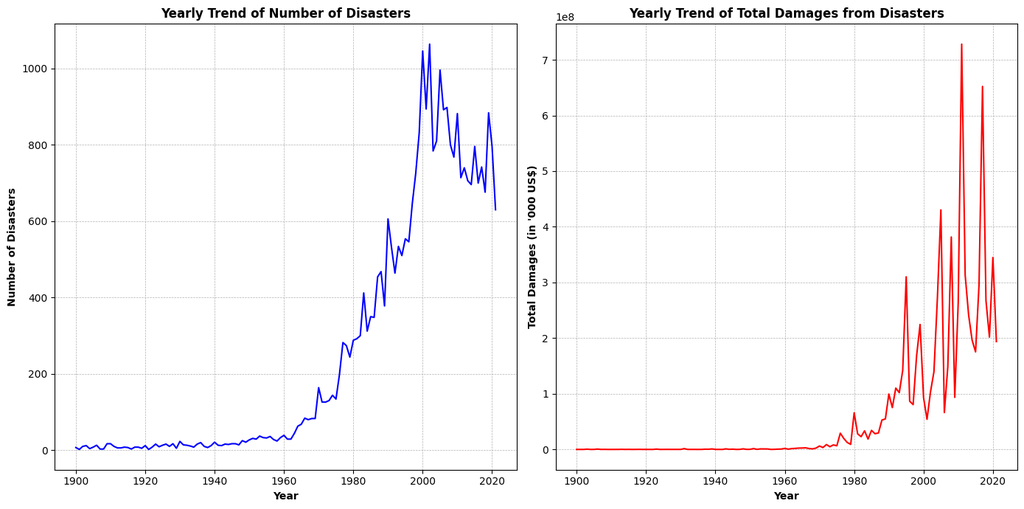

```python
# Yearly trend of number of disasters
yearly_disaster_counts = combined_dataset.groupby('Year').size()

# Yearly trend of total damages
yearly_total_damages = combined_dataset.groupby('Year')["Total Damages ('000 US$)"].sum()

plt.figure(figsize=(14, 7))

# Plotting number of disasters
plt.subplot(1, 2, 1)
yearly_disaster_counts.plot(color='blue')
plt.title('Yearly Trend of Number of Disasters', fontweight='bold')
plt.xlabel('Year', fontweight='bold')
plt.ylabel('Number of Disasters', fontweight='bold')
plt.grid(True, which='both', linestyle='--', linewidth=0.5)

# Plotting total damages
plt.subplot(1, 2, 2)
yearly_total_damages.plot(color='red')
plt.title('Yearly Trend of Total Damages from Disasters', fontweight='bold')
plt.xlabel('Year', fontweight='bold')
plt.ylabel('Total Damages (in \'000 US$)', fontweight='bold')
plt.grid(True, which='both', linestyle='--', linewidth=0.5)

plt.tight_layout()
plt.show()
```

The graphs provide the following insights:

1. **Yearly Trend of Number of Disasters:**
- There's a noticeable increase in the number of reported disasters from the mid-20th century onwards.
- The peak in the number of disasters seems to occur around the early 21st century.
1. **Yearly Trend of Total Damages from Disasters:**
- The economic damages from natural disasters show significant variability over the years.
- There are several pronounced spikes, especially in the late 20th and early 21st centuries, indicating years of particularly high economic damages.

Next, let's examine the distribution of different disaster types in the dataset to understand the most common types of disasters reported.

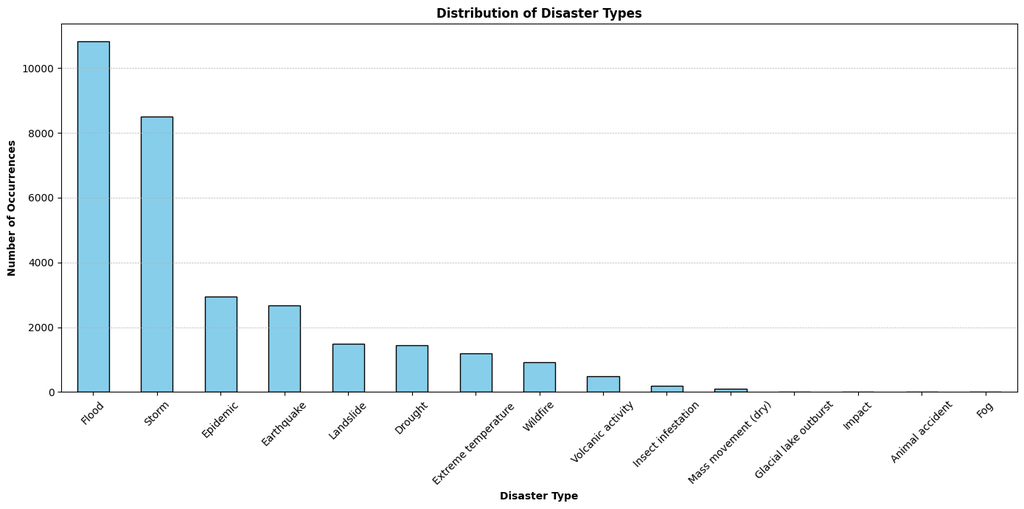

```python
# Distribution of disaster types
disaster_type_counts = combined_dataset['Disaster Type'].value_counts()

plt.figure(figsize=(14, 7))
disaster_type_counts.plot(kind='bar', color='skyblue', edgecolor='black')
plt.title('Distribution of Disaster Types', fontweight='bold')
plt.xlabel('Disaster Type', fontweight='bold')
plt.ylabel('Number of Occurrences', fontweight='bold')
plt.xticks(rotation=45)
plt.grid(axis='y', linestyle='--', linewidth=0.5)

plt.tight_layout()
plt.show()
```

Understanding the distribution of disaster types can help tailor the platform's features and resources to cater to the most common disaster scenarios.

## Canada-Specific Analysis

Now, let's shift our focus to Canada-specific insights. This includes:

- Examine the distribution of different disaster types in Canada.
- Analyze the trend of economic damages in Canada due to natural disasters over the years.

We'll begin by examining the distribution of different disaster types in Canada.

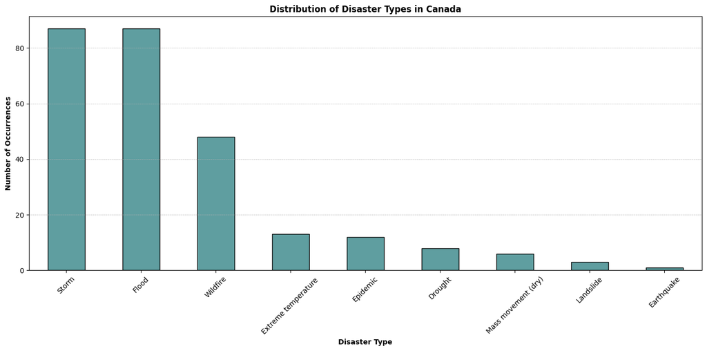

```python
# Extracting Canada-specific data
canada_data = combined_dataset[combined_dataset['Country'] == 'Canada']

# Distribution of disaster types in Canada
canada_disaster_type_counts = canada_data['Disaster Type'].value_counts()

plt.figure(figsize=(14, 7))
canada_disaster_type_counts.plot(kind='bar', color='cadetblue', edgecolor='black')
plt.title('Distribution of Disaster Types in Canada', fontweight='bold')
plt.xlabel('Disaster Type', fontweight='bold')
plt.ylabel('Number of Occurrences', fontweight='bold')
plt.xticks(rotation=45)
plt.grid(axis='y', linestyle='--', linewidth=0.5)

plt.tight_layout()
plt.show()
```

The bar chart displays the distribution of disaster types in Canada:

Next, we'll delve into the top 4 disaster types in Canada. We'll begin by analyzing the yearly occurrences for each of these disaster types.

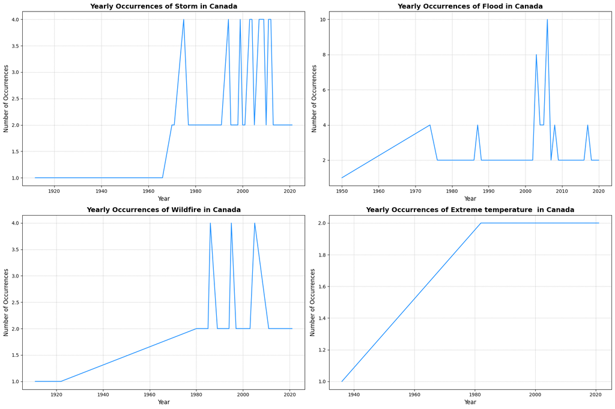

```python
# Top 4 disaster types in Canada
top_4_disasters_canada = canada_disaster_type_counts.head(4).index.tolist()

# Creating subplots for yearly occurrences of the top 4 disaster types
plt.figure(figsize=(18, 12))

for i, disaster_type in enumerate(top_4_disasters_canada, 1):
    yearly_occurrences = canada_data[canada_data['Disaster Type'] == disaster_type].groupby('Year').size()

    plt.subplot(2, 2, i)
    yearly_occurrences.plot(color='dodgerblue')
    plt.title(f'Yearly Occurrences of {disaster_type} in Canada', fontweight='bold', fontsize=14)
    plt.xlabel('Year', fontsize=12)
    plt.ylabel('Number of Occurrences', fontsize=12)
    plt.grid(True, which='both', linestyle='--', linewidth=0.5)

plt.tight_layout()
plt.show()
```

Next, we'll analyze the trend of economic damages in Canada due to natural disasters over the years. This will provide insights into the economic impact of these events on the country.

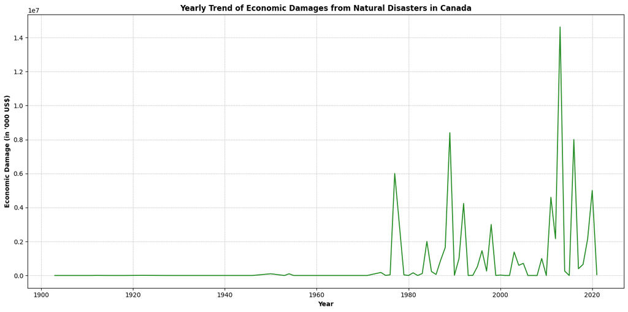

```python
# Yearly trend of economic damages in Canada due to natural disasters
yearly_damages_canada = canada_data.groupby('Year')["Total Damages ('000 US$)"].sum()

plt.figure(figsize=(14, 7))
yearly_damages_canada.plot(color='forestgreen')
plt.title('Yearly Trend of Economic Damages from Natural Disasters in Canada', fontweight='bold')
plt.xlabel('Year', fontweight='bold')
plt.ylabel('Economic Damage (in \'000 US$)', fontweight='bold')
plt.grid(True, which='both', linestyle='--', linewidth=0.5)

plt.tight_layout()
plt.show()
```

The graph showcases the yearly trend of economic damages in Canada due to natural disasters:

- From the mid-20th century, there's a clear upward trend in economic damages. The late 20th century and early 21st century have several pronounced spikes, indicating years with particularly high economic impacts.
- These spikes emphasize the increasing economic challenges that natural disasters pose to Canada, necessitating proactive response and management.

Now, let's analyze the economic damages over the years for each of these top 4 disaster types in Canada.

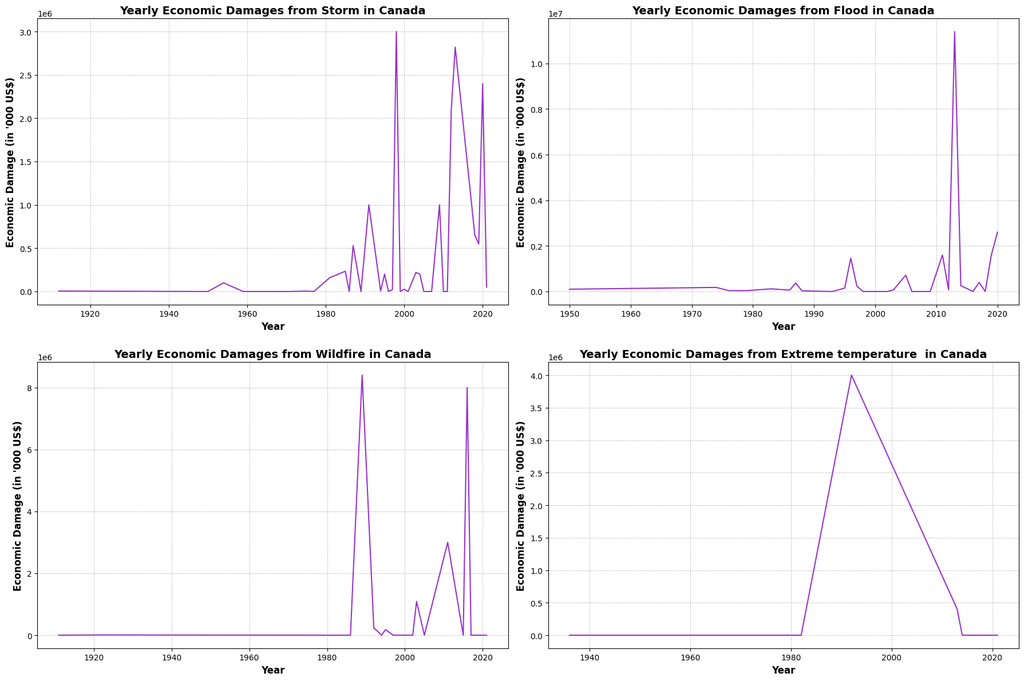

```python
# Creating subplots for yearly economic damages of the top 4 disaster types in Canada
plt.figure(figsize=(18, 12))

for i, disaster_type in enumerate(top_4_disasters_canada, 1):
    yearly_damages_type = canada_data[canada_data['Disaster Type'] == disaster_type].groupby('Year')["Total Damages ('000 US$)"].sum()

    plt.subplot(2, 2, i)
    yearly_damages_type.plot(color='darkorchid')
    plt.title(f'Yearly Economic Damages from {disaster_type} in Canada', fontweight='bold', fontsize=14)
    plt.xlabel('Year', fontweight='bold', fontsize=12)
    plt.ylabel('Economic Damage (in \'000 US$)', fontweight='bold', fontsize=12)
    plt.grid(True, which='both', linestyle='--', linewidth=0.5)

plt.tight_layout()
plt.show()
```

These insights highlight the varying economic challenges posed by different disaster types in Canada. While some disasters may occur frequently, their economic impact can differ significantly based on the severity and affected regions.

Next, we will proceed with the analysis of deaths over the years for each of the top 4 disaster types in Canada.

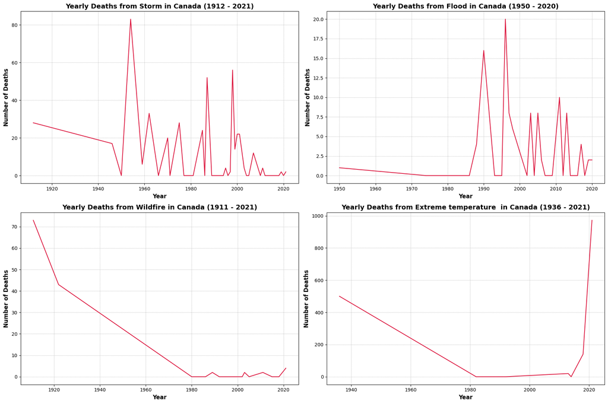

```python
# Creating subplots for yearly deaths of the top 4 disaster types in Canada
plt.figure(figsize=(18, 12))

for i, disaster_type in enumerate(top_4_disasters_canada, 1):
    yearly_deaths_type = canada_data[canada_data['Disaster Type'] == disaster_type].groupby('Year')["Total Deaths"].sum()

    plt.subplot(2, 2, i)
    yearly_deaths_type.plot(color='crimson')
    plt.title(f'Yearly Deaths from {disaster_type} in Canada ({yearly_deaths_type.index.min()} - {yearly_deaths_type.index.max()})', fontweight='bold', fontsize=14)
    plt.xlabel('Year', fontweight='bold', fontsize=12)
    plt.ylabel('Number of Deaths', fontweight='bold', fontsize=12)
    plt.grid(True, which='both', linestyle='--', linewidth=0.5)

plt.tight_layout()
plt.show()
```

With these insights, we have provided a comprehensive view of the challenges posed by natural disasters in Canada, both in terms of economic damages and the loss of life.

## Insights Summary

With these analyses, we now have a comprehensive view of both global and Canada-specific insights regarding natural disasters. These insights are instrumental in understanding the scope, scale, and specific nuances of the challenges posed by natural disasters, thereby informing the design and features of our crisis response and management platform:

- Natural disasters have caused increasing economic damages globally, with pronounced spikes in the late 20th and early 21st centuries.
- Floods and storms are the most common disaster types globally and in Canada.
- The economic and human impact of natural disasters is highly variable, emphasizing the unpredictability and devastating potential of these events.
- Preparedness and rapid response mechanisms are crucial to mitigate the impacts of these disasters.

## Conclusion

Understanding the patterns and impacts of natural disasters is essential for effective crisis response and management. With the insights derived from this analysis, we can make informed decisions, allocate resources more effectively, and design platforms and initiatives that address the most pressing challenges posed by natural disasters.